# Milestone Report

Thad Truman

Saturday, November 15, 2014

### The Data

The training set consists of three files, each from a different web source; twitter, news sites, and blogs.

Below is table listing the amount of entries, words, and maximum character count for each data set.

| Data.Type | Entries | Total.Words | Max.Word.Count |
| --- | --- | --- | --- |
| Twitter | 2360148 | 162384825 | 213 |
| Blogs | 899288 | 208361438 | 40835 |
| News | 77259 | 15683765 | 5760 |

## Plots

To explore the data I took a random sample of 50,000 entries from each data source.

The below plot shows the 20 most frequent words in the text and their frequency. As expected the most frequent words are common articles, pronouns, and prepositions.

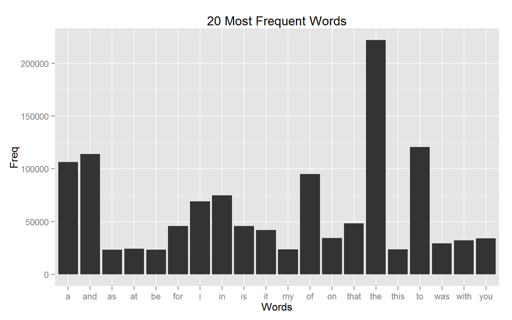

The below image shows the 200 most frequent words. The size of the word is indicative of it’s frequency in the text.

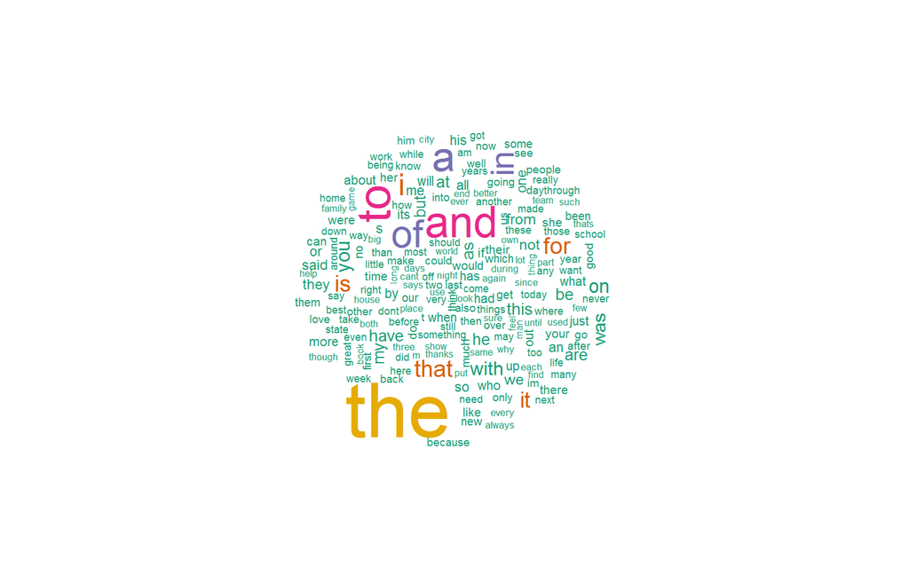

Below are the same two plots but with the most common “stop words” removed. Stop words are articles, prepositions, pronouns, etc. This leaves us with words that convey more meaning.

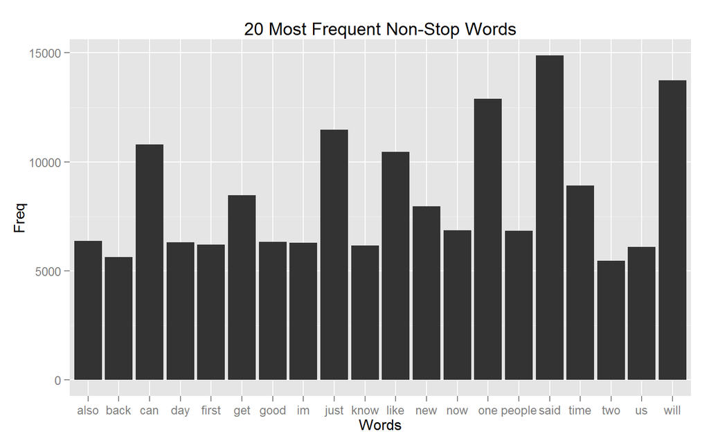

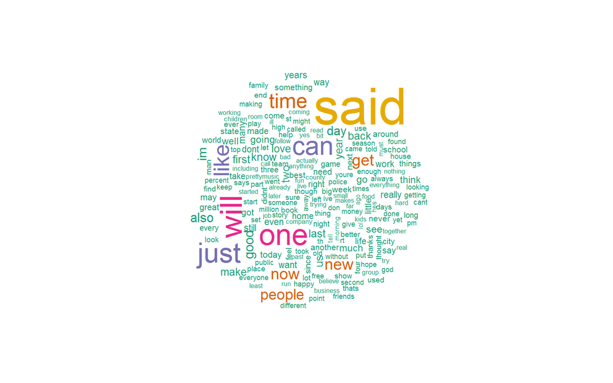

Along with identifying the most common words, it can be helpful to determine the most frequent series of words. The below plot shows the most frequent three-word groups in the text.

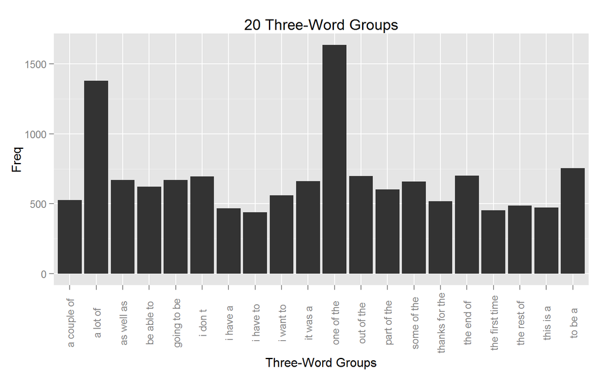

## Next Steps

Going forward it will be necessary to include more data in the process, and find a smart way to pare down, leaving the most valuable. It may also be necessary to look at the relationships of non-stop words to each other in order to improve prediction on out of sample phrases.

- The .RMD code is available here http://github.com/TBT8/DS-MilestoneProject